# Statistical Inference Course Project Part 1

Ignacio Ojea

June 2, 2018

## Assignment 1

In this project you will investigate the exponential distribution in R and compare it with the Central Limit Theorem. The exponential distribution can be simulated in R with rexp(n, lambda) where lambda is the rate parameter. The mean of exponential distribution is 1/lambda and the standard deviation is also 1/lambda. Set lambda = 0.2 for all of the simulations. You will investigate the distribution of averages of 40 exponentials. Note that you will need to do a thousand simulations.

We begin by assigning the relevant parameters:

```r
lambda <- 0.2     # labmda
n.exp <- 40       # number of exponentials
n.sims <- 1000    # number of simulations
set.seed(2018)
```

We then proceed to run the simulations:

```r
simulation.data <- as.data.frame(replicate(n.sims, rexp(n.exp, lambda)))
```

## Assignment 2: Sample Mean vs Theoretical Mean

Let us find the sample means:

```r
data.means <- apply(simulation.data, 2, mean)
```

The theoretical mean of exponential distribution is 1/lambda. In our case, this corresponds to 1/(2/10) = 10/2 = 5. The simulation sample mean is:

```r
mean(data.means)
```

```
## [1] 5.020107
```

Which is very close to the theoretical mean.

Let us now create a plot in order to compare the theoretical mean and the simulations mean:

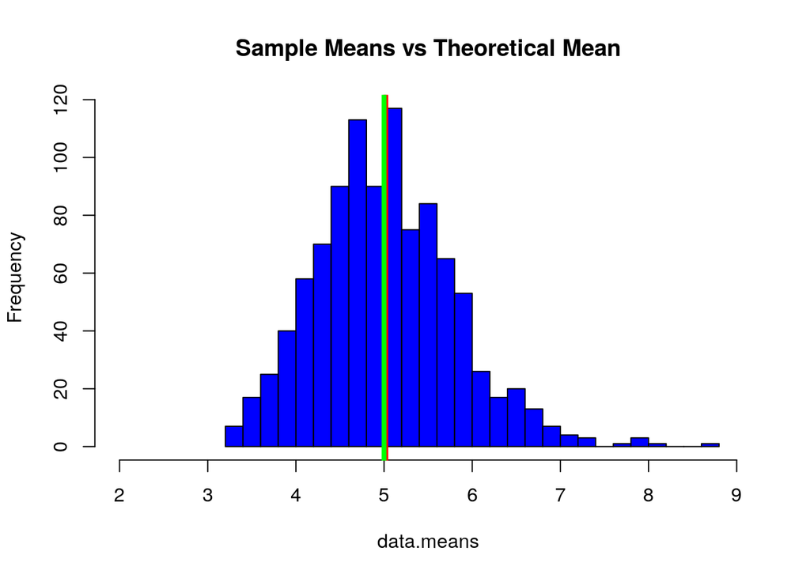

```r
hist(data.means, breaks=30, xlim = c(2,9), main="Sample Means vs Theoretical Mean", col = "blue")
abline(v=mean(data.means), lwd="4", col="red")        # Simulation Mean
abline(v=5, lwd="4", col="green")        # Theoretical Mean
```

## Assignment 3: Sample Variance vs Theoretical Variance From CLT, we know the theoretical standard deviation of the mean is (1 / lambda) / sqrt(n), and the variance is (1 / lambda)^2 / n. Let us now compare:

```r
print(paste("Theoretical variance: ", round( ((1/lambda)/sqrt(n.exp))^2 ,5)))
```

```
## [1] "Theoretical variance:  0.625"
```

```r
print(paste("Sample variance: ", round(var(data.means) ,5) ))
```

```
## [1] "Sample variance:  0.62613"
```

```r
print(paste("Theoretical standard deviation: ", round( (1/lambda)/sqrt(n.exp) ,5)))
```

```
## [1] "Theoretical standard deviation:  0.79057"
```

```r
print(paste("Sample standard deviation: ", round( sd(data.means),5)))
```

```
## [1] "Sample standard deviation:  0.79129"
```

The results show that variances are very close, as well as standar deviations.

## Assignment 2: Approximation to normality

Finally, let us investigate if the exponential distribution is approximately normal. We know from the CLT that the averages of samples should follow a normal distribution as samples increase in number.

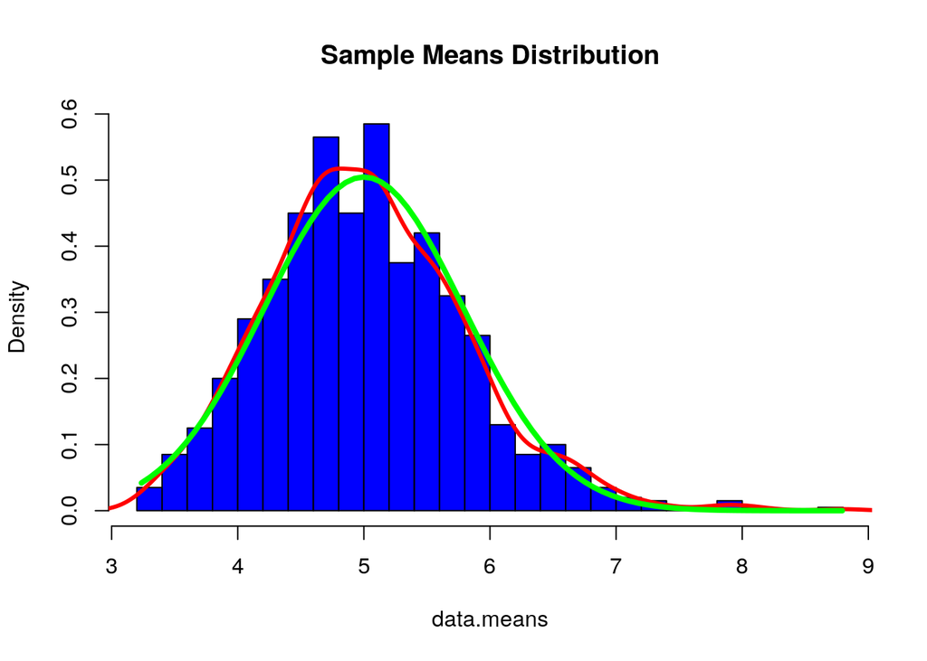

```r
#Plotting of the mean distribution of the samples
hist(data.means, breaks = 30, prob=TRUE, col="blue", main="Sample Means Distribution")
lines(density(data.means), lwd=3, col="red")

#Plotting of the normal distribution line
x <- seq(min(data.means), max(data.means), length=2*n.exp)
y <- dnorm(x, mean=1/lambda, sd=sqrt(((1/lambda)/sqrt(n.exp))^2))
lines(x, y, pch=22, col="green", lwd=4)
```